# Mixed Effects Models Simulations

Robert Long

27/06/2021

Flexibly simulating data for a mixed effects model with random intercepts and random slopes for a numeric variable including the correlation between slopes and intercepts.

I have been using the following code, and variations on it for a number of years in my own research, and to help me answer questions on CrossValidated related to mixed models. [Here](https://stats.stackexchange.com/search?tab=votes&q=user%3a7486%20%5bmixed-model%5d) is a link to all the mixed model questions I have answered there.

We will work with a dataset consisting of a single explanatory variable `X`, and a grouping variable `G`. There are several ways we can set this up, but for simplicity, initially we will deal with balanced groups containing a fixed number of values for `X`. Later we will relax this to handle unbalanced groups as well as randomly generated values for `X`, and more complex models generally.

We will work with the general formula for mixed effects models:

$$Y = \mathbf{X} \mathbf{\beta} + \mathbf{Zu} + \mathbf{\epsilon}$$
where $\mathbf{X}$ is the $n \times p$ model matrix for the fixed effects, $\mathbf{\beta}$ is the $p \times 1$ fixed effects coefficient vector, $\textbf{Z}$ is the $n×q$ model matrix for the $q$-dimensional vector-valued random-effects variable $\textbf{u}$, and $\mathbf{\epsilon}$ is the error term vector.

### Simulation of a single dataset

```r
n_group <- 6

dt <- expand.grid(G = 1:n_group, X = 1:5)
```

Here we are forming the dataframe we will use.

Now we create the model matrix for the fixed effects

```r
X <- model.matrix( ~ X, data = dt)
```

For the model matrix for the random effects, `Z`, there are a few ways we can approach this, but the easiest is to make use of the `lFormula` function in `lme4`. To do this we need to add the outcome variable `Y` to the dataframe, but since we haven’t yet simulated it, we will just use a column of 1s since this will not affect `Z` in any way:

```r
library(lme4)
dt$Y <- 1
myFormula <- 'Y ~ X + (X | G)'

foo <- lFormula(eval(myFormula), dt)
Z <- t(as.matrix(foo$reTrms$Zt))
```

Now we set the remaining parameters for the simulation: the fixed effects (`betas`), random effects standard deviations (`s1` and `s2`), the residual standard error (`eps`) and the correlation between these, `rho`:

```r
betas <- c(1, 1) # Fixed effects parameters

s1 <- 2   #  SD of random intercepts
s2 <- 1   #  SD of random slopes

eps <- 1  # SD of residual error

rho <- -0.9  # correlation between intercepts and slopes
```

Next we form the variance-covariance matrix we will use to simulate the random effects:

```r
cormat <-  matrix(c(s1, rho, rho, s2), 2, 2)  # correlation matrix
covmat <- sdcor2cov(cormat)                   # covariance matrix (needed for mvrnorm)
```

Then we simulate the random effects, and the residual error:

```r
set.seed(1)

umat <- MASS::mvrnorm(n_group, c(0, 0), covmat, empirical = TRUE)  # simulate the random effects

u <- c(rbind(umat[, 1], umat[, 2]))  # lme4 needs the random effects in this order (interleaved)

e <- rnorm(nrow(dt), 0, eps)   # residual error
```

Note that I have used `set.seed()` in this block, since it occurs just before the first simulation. It is good practice to `set.seed()` at the top of a source file, but we will extend this code later where we use Monte-Carlo simulation and for that we would like to set a different seed for each simulation at this point.

Finally we can compute the simulated value for `Y` using the general mixed model equation above:

```r
dt$Y <- X %*% betas + Z %*% u + e

m0 <- lmer(myFormula, dt)
summary(m0)
```

```
## Linear mixed model fit by REML ['lmerMod']
## Formula: Y ~ X + (X | G)
##    Data: dt
##
## REML criterion at convergence: 103.9
##
## Scaled residuals:
##     Min      1Q  Median      3Q     Max
## -2.1003 -0.4614  0.2525  0.6513  1.2274
##
## Random effects:
##  Groups   Name        Variance Std.Dev. Corr
##  G        (Intercept) 4.6219   2.1499
##           X           1.0061   1.0031   -0.95
##  Residual             0.9125   0.9553
## Number of obs: 30, groups:  G, 6
##
## Fixed effects:
##             Estimate Std. Error t value
## (Intercept)   0.8895     0.9683   0.919
## X             1.0373     0.4277   2.425
##
## Correlation of Fixed Effects:
##   (Intr)
## X -0.931
```

In this case we see that we can recover all the parameters well:

- residual standard deviation is estimated as 0.9553 vs 1.0 simulated
- standard deviation for the random intercept: 2.1499 vs 2.0
- standard deviation for the random slopes: 1.0031 vs 1.0
- correlation between slopes and intercepts: -0.95 vs -0.9
- fixed effects of 0.8895 and 1.0373 vs 1.0 and 1.0 respectively

Of course, these are not *exactly* correct, and we would never expect them to be. One major area of interest is whether the estimates are *unbiased*, and to investigate this we can use Monte-Carlo simulation

### Monte Carlo Simulation to assess possible bias of estimates

The approach is as follows:

- set all variables and parameters for the simulation
- declare and assign storage for vectors which will hold the parameter estimates for each simulation
- we will run `n_sim` simulations
- we loop `n_sim` times, each time setting a unique seed
- we need to check that the model has converged and that it has non converged to a singular fit. For this we will use the following little helper function:

```r
hasConverged <- function (mm) {

  if ( !(class(mm)[1] == 'lmerMod' | class(mm)[1] == 'lmerModLmerTest'))  stop('Error must pass a lmerMod object')

  retval <- NULL

  if(is.null(unlist(mm@optinfo$conv$lme4))) {
    retval = 1
  }
  else {
    if (isSingular(mm)) {
      retval = 0
    } else {
      retval = -1
    }
  }
  return(retval)
}
```

This function returns 1 if the model has converged (not to a singular fit).

Note that, the code that follows is essentially the same as the code above with the addition of the loop and the vectors used for saving the estimates.

```r
n_group <- 6

dt <- expand.grid(G = 1:n_group, X = 1:5)

X <- model.matrix( ~ X, data = dt)

dt$Y <- 1
myFormula <- 'Y ~ X + (X | G)'

foo <- lFormula(eval(myFormula), dt)
Z <- t(as.matrix(foo$reTrms$Zt))

betas <- c(1, 1) # Fixed effects parameters

s1 <- 2   #  SD of random intercepts
s2 <- 1   #  SD of random slopes

eps <- 1  # SD of residual error

rho <- -0.9  # correlation between intercepts and slopes
cormat <-  matrix(c(s1, rho, rho, s2), 2, 2)
covmat <- sdcor2cov(cormat) # this function is from lme4

n_sim <- 100
vec_s1 <- vec_s2 <- vec_eps <- vec_rho <- vec_fe1 <- vec_fe2 <- numeric(n_sim)
vec_s1 <- vec_s2 <- vec_eps <- vec_rho <- vec_fe1 <- vec_fe2 <- rep(NA, n_sim)

for (i in 1:n_sim) {
  set.seed(i)

  umat <- MASS::mvrnorm(n_group, c(0, 0), covmat, empirical = TRUE)

  u <- c(rbind(umat[, 1], umat[, 2]))

  e <- rnorm(nrow(dt), 0, eps)

  dt$Y <- X %*% betas + Z %*% u + e

  m0 <- lmer(myFormula, dt)

  tmp_dt <- data.frame(VarCorr(m0))

  if (hasConverged(m0) == 1) {
    vec_s1[i] <- tmp_dt[1,5]
    vec_s2[i] <- tmp_dt[2,5]
    vec_rho[i] <- tmp_dt[3,5]
    vec_eps[i] <- tmp_dt[4,5]
    vec_fe1[i] <- coef(summary(m0))[1]
    vec_fe2[i] <- coef(summary(m0))[2]
  }
}
```

```
## boundary (singular) fit: see ?isSingular
## boundary (singular) fit: see ?isSingular
## boundary (singular) fit: see ?isSingular
## boundary (singular) fit: see ?isSingular
```

```
## boundary (singular) fit: see ?isSingular
## boundary (singular) fit: see ?isSingular
```

```r
sum(is.na(vec_s1))
```

```
## [1] 7
```

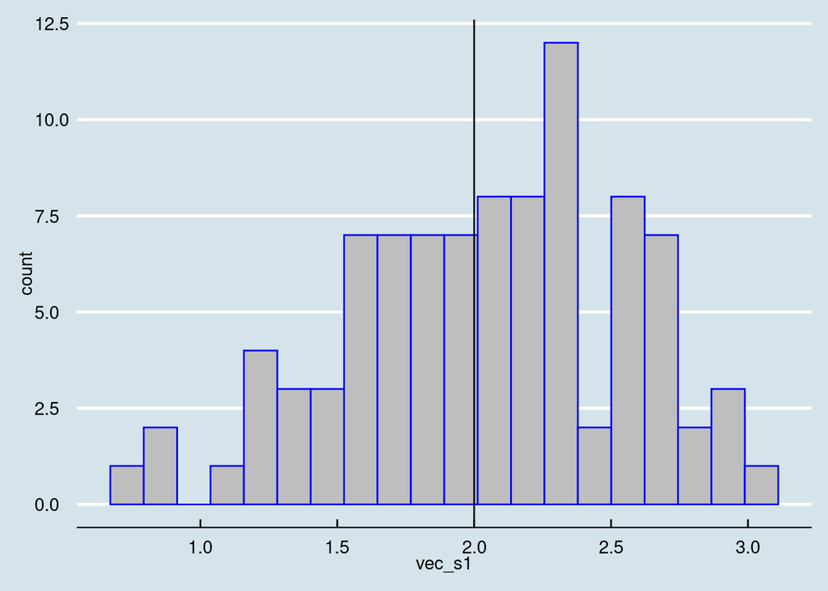

```r
library(ggplot2)
library(ggthemes)
ggplot(data.frame(vec_s1), aes(x = vec_s1)) + geom_histogram(colour = 'blue', fill = 'grey', bins = 20 ) + geom_vline(aes(xintercept = s1), colour =  'black') + theme_economist() +  scale_color_economist()
```

```r
mean(vec_s1, na.rm = TRUE)
```

```
## [1] 2.039515
```

So we find that the estimate is unbiased. The mean of the simulations is 2.04 and the actual value used to create the simulations was 2, and we have plotted a vertical line on the histogram to show this. We can now follow the same procedures for the other estimates:

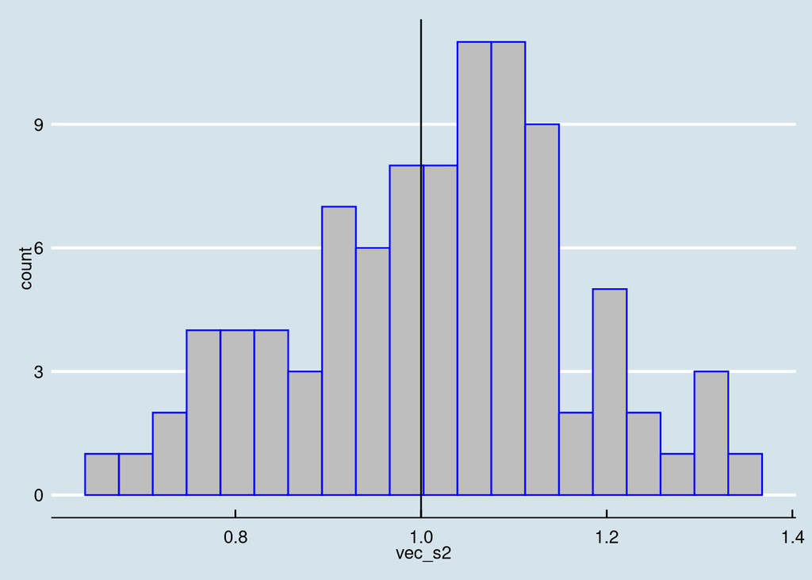

```r
ggplot(data.frame(vec_s2), aes(x = vec_s2)) + geom_histogram(colour = 'blue', fill = 'grey', bins = 20 ) + geom_vline(aes(xintercept = s2), colour =  'black') + theme_economist() +  scale_color_economist()
```

```r
mean(vec_s2, na.rm = TRUE)
```

```
## [1] 1.012603
```

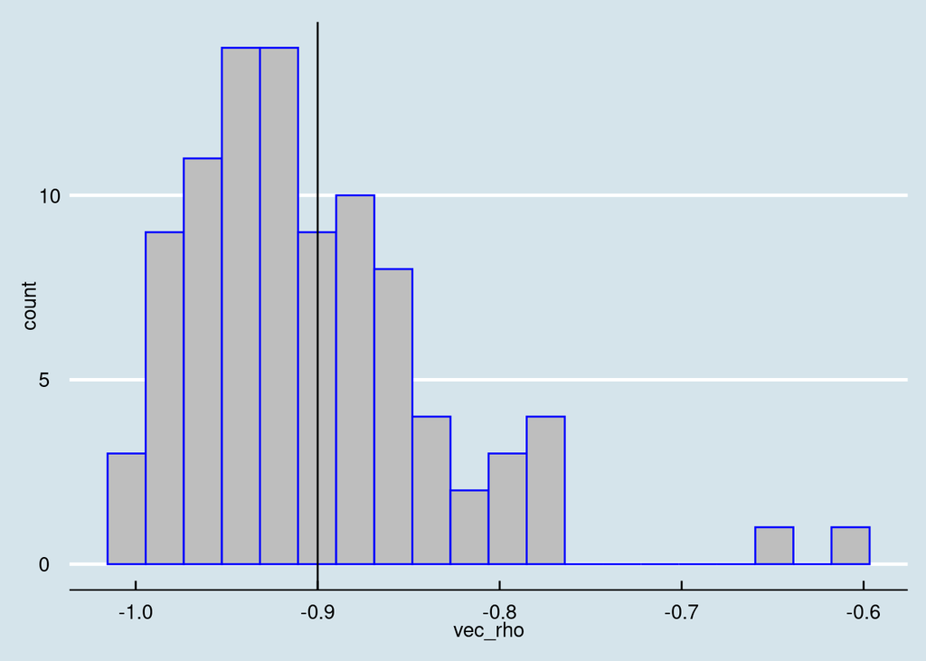

```r
ggplot(data.frame(vec_rho), aes(x = vec_rho)) + geom_histogram(colour = 'blue', fill = 'grey', bins = 20 )+ geom_vline(aes(xintercept = rho), colour =  'black') + theme_economist() +  scale_color_economist()
```

```r
mean(vec_rho, na.rm = TRUE)
```

```
## [1] -0.9036961
```

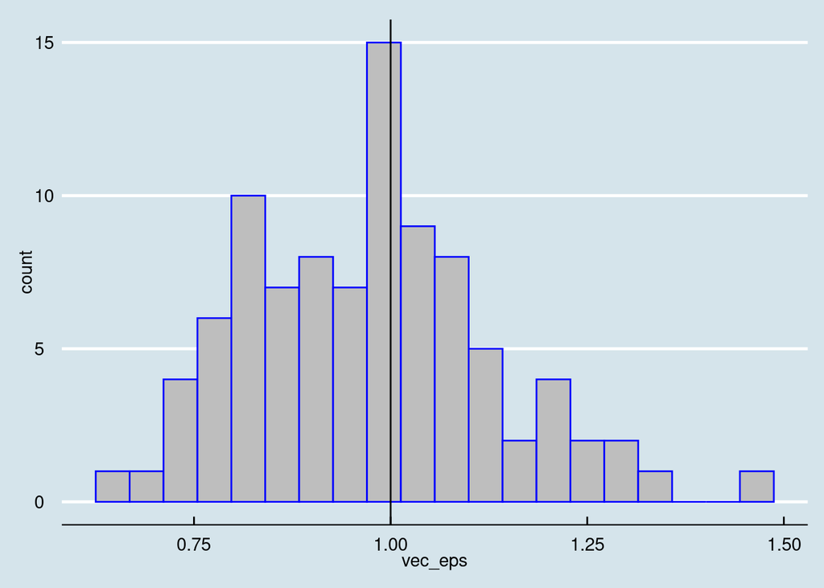

```r
ggplot(data.frame(vec_eps), aes(x = vec_eps)) + geom_histogram(colour = 'blue', fill = 'grey', bins = 20 )+ geom_vline(aes(xintercept = eps), colour =  'black') + theme_economist() +  scale_color_economist()
```

```r
mean(vec_eps, na.rm = TRUE)
```

```
## [1] 0.9732599
```

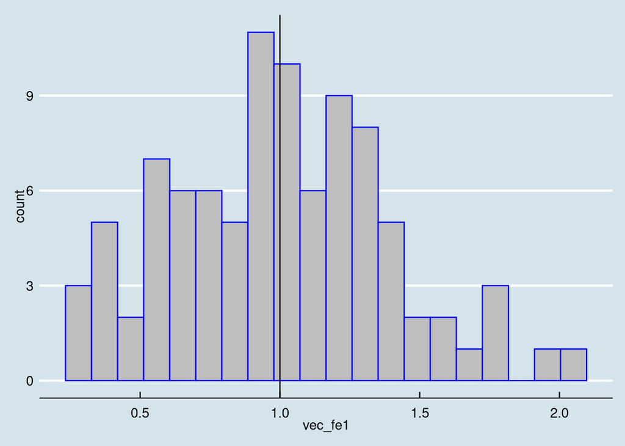

```r
ggplot(data.frame(vec_fe1), aes(x = vec_fe1)) + geom_histogram(colour = 'blue', fill = 'grey', bins = 20 )+ geom_vline(aes(xintercept = betas[1]), colour =  'black') + theme_economist() +  scale_color_economist()
```

```r
mean(vec_fe1, na.rm = TRUE)
```

```
## [1] 0.9964722
```

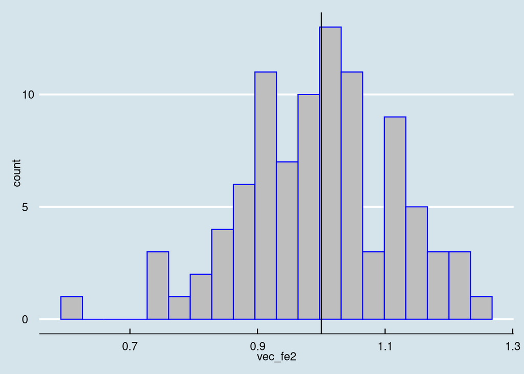

```r
ggplot(data.frame(vec_fe2), aes(x = vec_fe2)) + geom_histogram(colour = 'blue', fill = 'grey', bins = 20 )+ geom_vline(aes(xintercept = betas[2]), colour =  'black') + theme_economist() +  scale_color_economist()
```

```r
mean(vec_fe2, na.rm = TRUE)
```

```
## [1] 0.9947593
```

So we find that all the estimates are unbiased. The main point of concern is that there is quite a wide spread of estimates. This is likely due, at least in part to the small number of clusters.

### Increasing the cluster size

If we change

```
n_group <- 6
```

to

```r
n_group <- 100
```

and re-run the simulations, then we obtain:

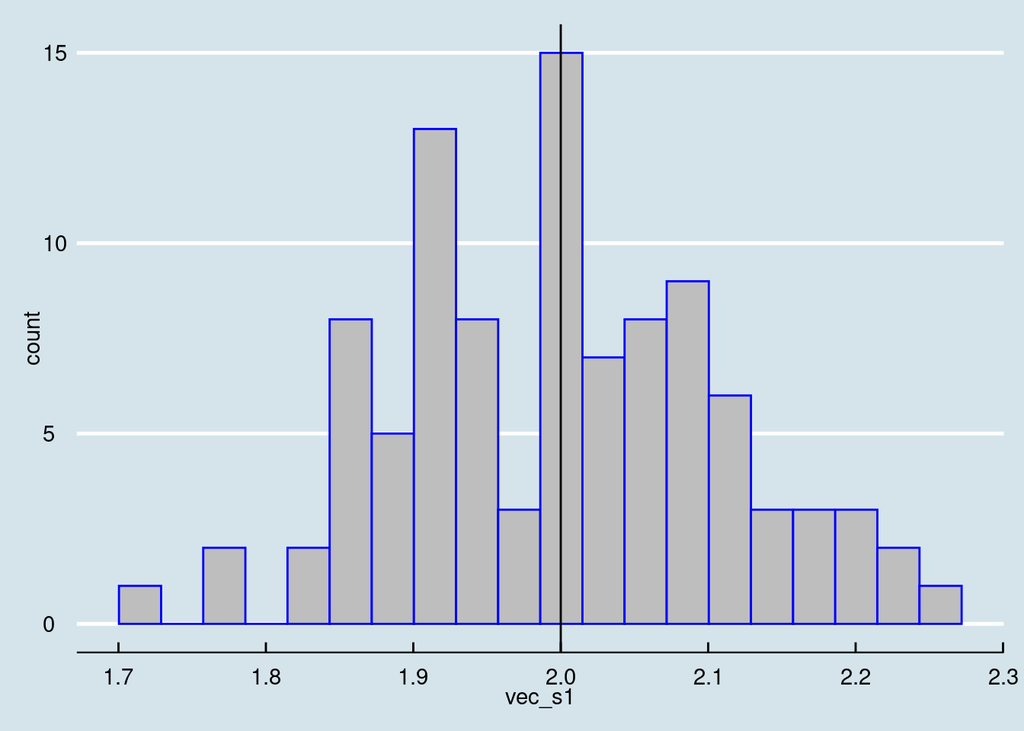

```r
ggplot(data.frame(vec_s1), aes(x = vec_s1)) + geom_histogram(colour = 'blue', fill = 'grey', bins = 20 ) + geom_vline(aes(xintercept = s1), colour =  'black') + theme_economist() +  scale_color_economist()
```

```r
mean(vec_s1, na.rm = TRUE)
```

```
## [1] 2.00038
```

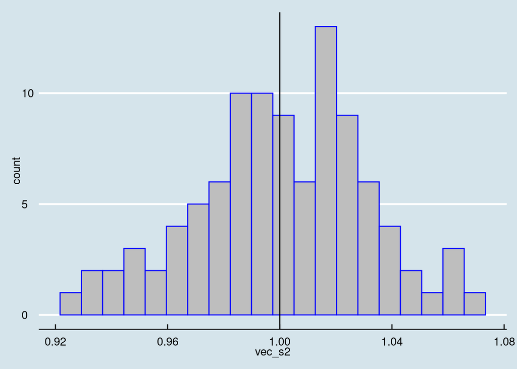

```r
ggplot(data.frame(vec_s2), aes(x = vec_s2)) + geom_histogram(colour = 'blue', fill = 'grey', bins = 20 ) + geom_vline(aes(xintercept = s2), colour =  'black') + theme_economist() +  scale_color_economist()
```

```r
mean(vec_s1, na.rm = TRUE)
```

```
## [1] 2.00038
```

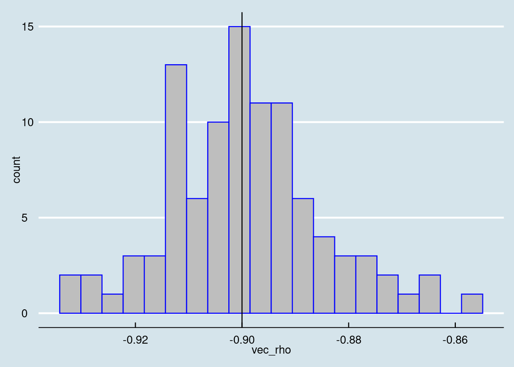

```r
ggplot(data.frame(vec_rho), aes(x = vec_rho)) + geom_histogram(colour = 'blue', fill = 'grey', bins = 20 )+ geom_vline(aes(xintercept = rho), colour =  'black') + theme_economist() +  scale_color_economist()
```

```r
mean(vec_rho, na.rm = TRUE)
```

```
## [1] -0.8994075
```

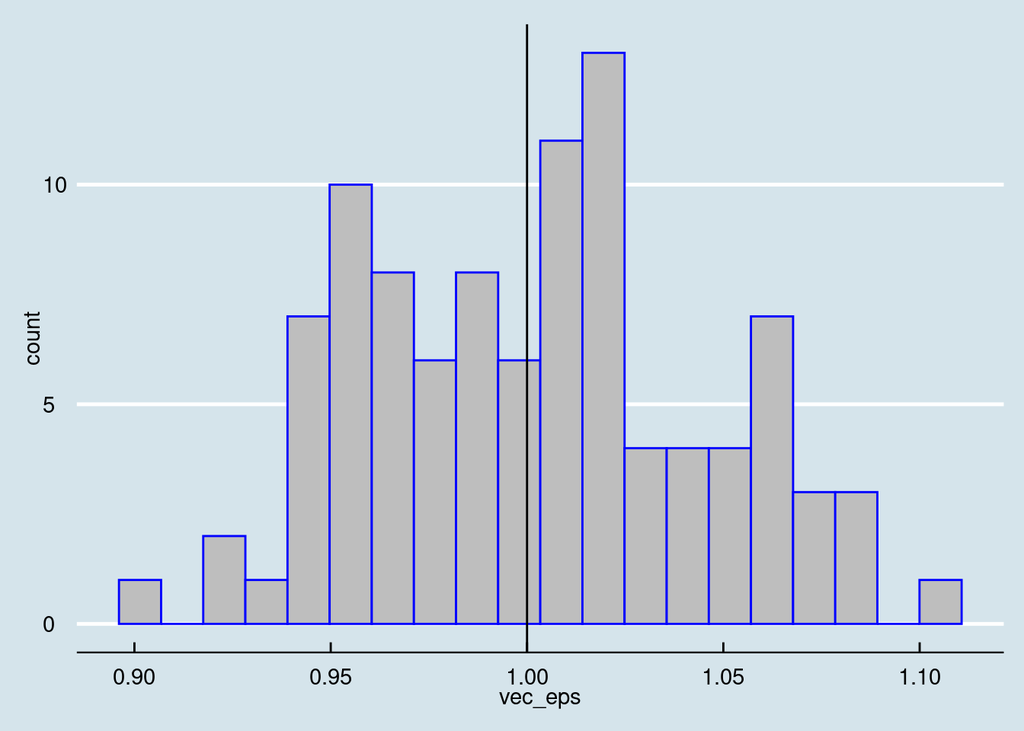

```r
ggplot(data.frame(vec_eps), aes(x = vec_eps)) + geom_histogram(colour = 'blue', fill = 'grey', bins = 20 ) + geom_vline(aes(xintercept = eps), colour =  'black') + theme_economist() +  scale_color_economist()
```

```r
mean(vec_eps, na.rm = TRUE)
```

```
## [1] 1.001352
```

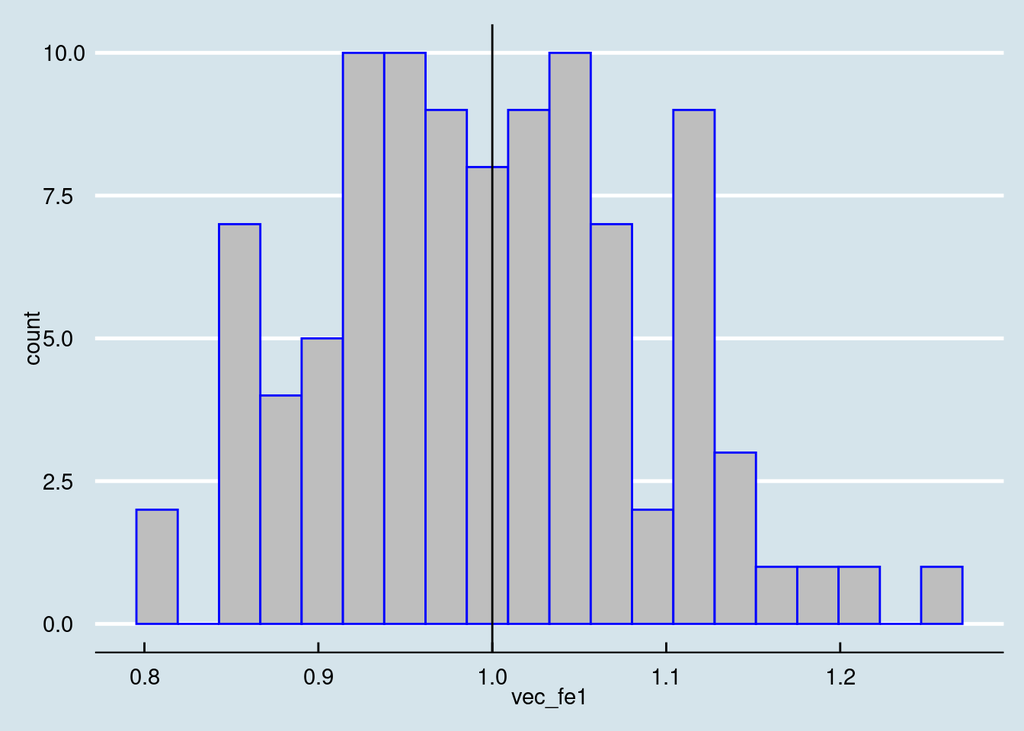

```r
ggplot(data.frame(vec_fe1), aes(x = vec_fe1)) + geom_histogram(colour = 'blue', fill = 'grey', bins = 20 ) + geom_vline(aes(xintercept = betas[1]), colour =  'black') + theme_economist() +  scale_color_economist()
```

```r
mean(vec_fe1, na.rm = TRUE)
```

```
## [1] 0.9979048
```

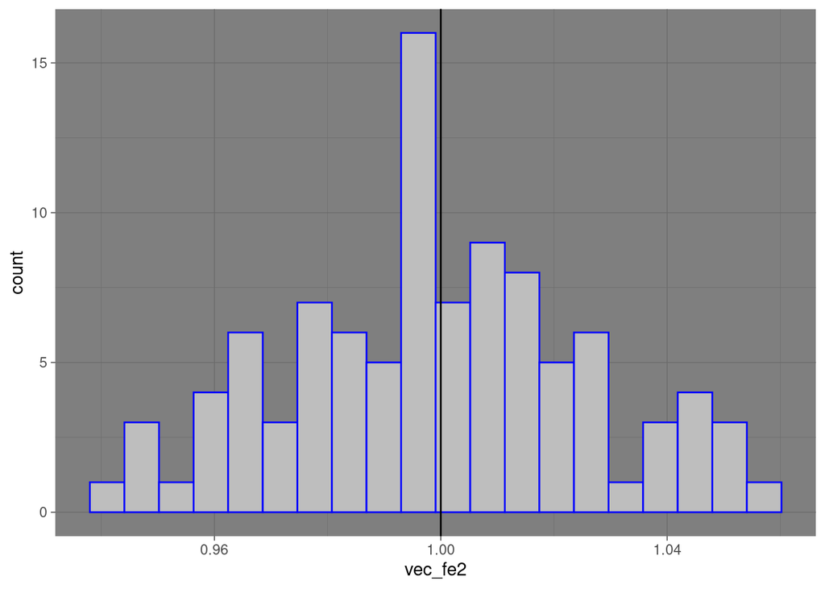

```r
ggplot(data.frame(vec_fe2), aes(x = vec_fe2)) + geom_histogram(colour = 'blue', fill = 'grey', bins = 20 ) + geom_vline(aes(xintercept = betas[2]), colour =  'black') + theme_dark()
```

```r
mean(vec_fe2, na.rm = TRUE)
```

```
## [1] 0.999136
```

We can see from the above that the estimates are much better behaved with a larger number of clusters.

Next time we will look at unbalanced clusters and models with a more complex random structure.